# Predicting Exercise Correctness

Brian Lee Weeden

Sunday, December 14, 2014

### Abstract

The goal of this analysis is to use data collected from wearable tech devices to predict whether certain excercises are performed correctly or not. A random forest model was constructed on the original training data. Out of sample accuracy was estimated to be 99.32%. The model was run against a validation data set of 20 samples (the test set from the assignment), and the model correctly predicted all 20.

### The Data

The data that was used for this assignment was collected from sensors that were placed on weight lifters. The weight lifters were then told to do a weight lifting excercise in one of five ways: correctly, and four common beginner errors. The original dataset is available at http://groupware.les.inf.puc-rio.br/har.

Let’s take a look at a few boxplots to see how some of the variables are related to the outcome:

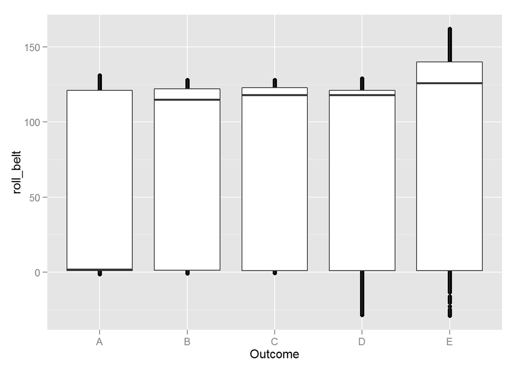

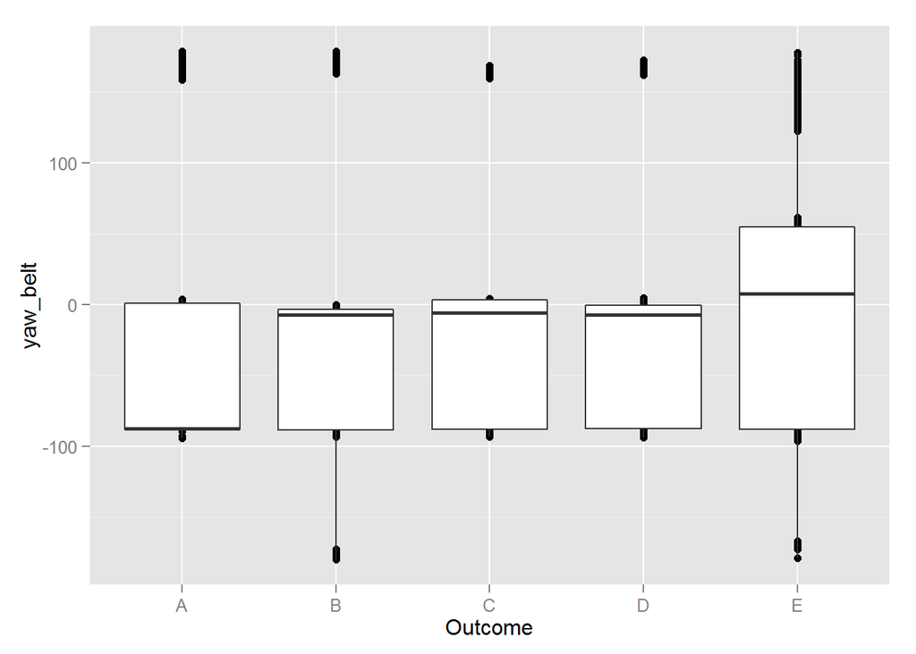

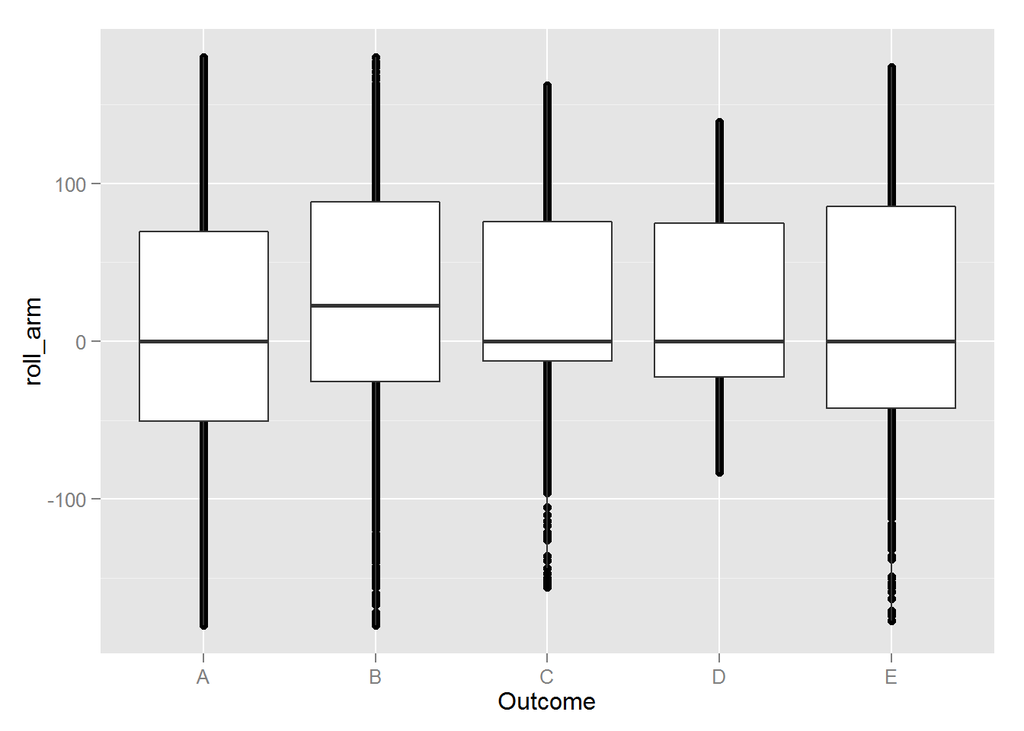

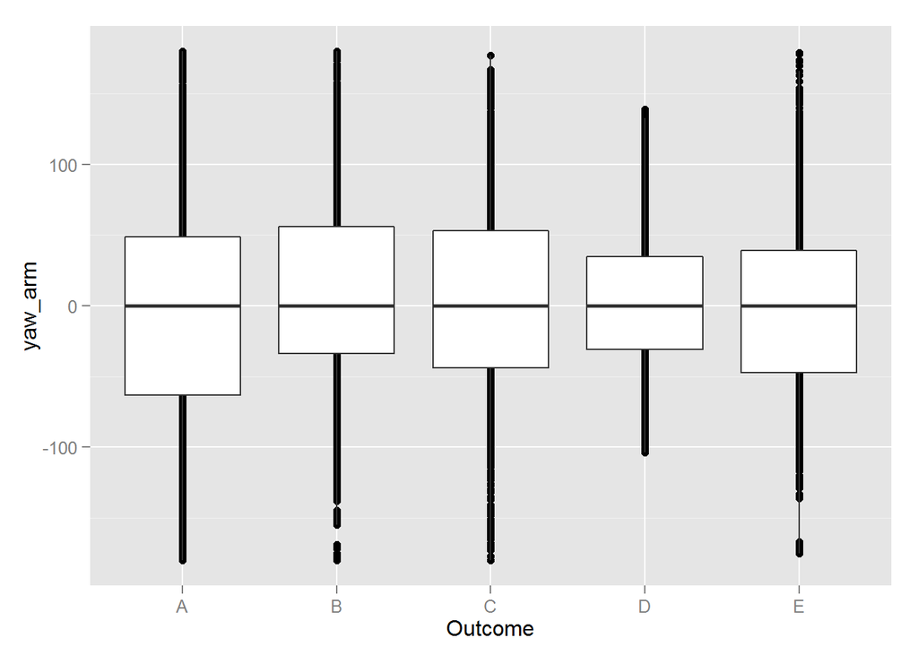

The outcomes are split into five classes, A-E. A is the correct way of doing the excercise, and B-E are each classificatons of an incorrect way. You can see from the charts that the belt sensors may be supplying more information than the arm sensors, based on seeing the spread between class A and the other classes in the median of the data. You can also see that the roll sensors may supply more information than the yaw sensors. The random forest modeling approach does afford an automatic way to select and rank the predictors, so we’ll find out below whether those observations are corroborated by the model.

### Building the Model

> In random forests, there is no need for cross-validation or a separate test set to get an unbiased estimate of the test set error. It is estimated internally, during the run, as follows: Each tree is constructed using a different bootstrap sample from the original data. About one-third of the cases are left out of the bootstrap sample and not used in the construction of the kth tree. Put each case left out in the construction of the kth tree down the kth tree to get a classification. In this way, a test set classification is obtained for each case in about one-third of the trees. At the end of the run, take j to be the class that got most of the votes every time case n was oob. The proportion of times that j is not equal to the true class of n averaged over all cases is the oob error estimate. This has proven to be unbiased in many tests. Leo Breiman and Adele Cutler, Random Forests, https://www.stat.berkeley.edu/~breiman/RandomForests/cc_home.htm

Here are the statistics for the model as generated by r:

```r
rf_model
```

```
## Random Forest
##
## 19622 samples
##    52 predictor
##     5 classes: 'A', 'B', 'C', 'D', 'E'
##
## No pre-processing
## Resampling: Bootstrapped (25 reps)
##
## Summary of sample sizes: 19622, 19622, 19622, 19622, 19622, 19622, ...
##
## Resampling results across tuning parameters:
##
##   mtry  Accuracy   Kappa      Accuracy SD  Kappa SD
##    2    0.9932392  0.9914485  0.001204418  0.001523310
##   27    0.9929789  0.9911192  0.001298828  0.001642275
##   52    0.9863955  0.9827912  0.003425168  0.004331582
##
## Accuracy was used to select the optimal model using  the largest value.
## The final value used for the model was mtry = 2.
```

The caret package call that was used to build the model was train(classe~., method=“rf”, data=“data2”).

Let’s take a look at the variable importance ranking in the random forest, as shown by the amount of decrease in the gini impurity critereon for each predictor added:

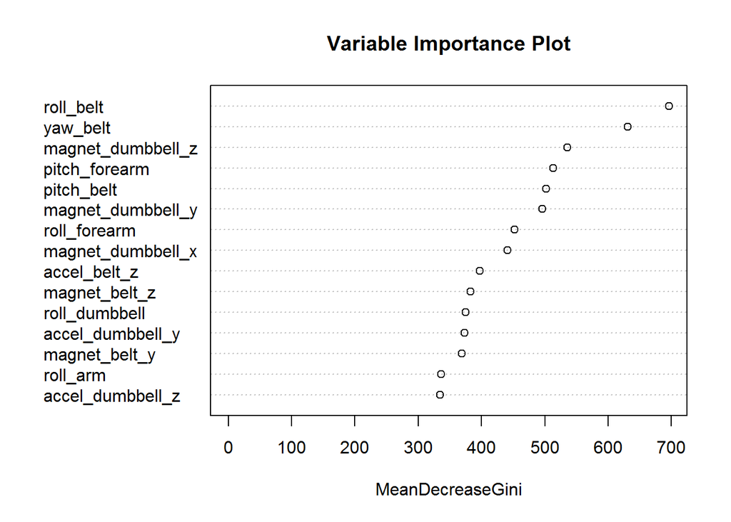

Based on this plot, it appears that the most important sensors are those on the belt. You can see that the roll, yaw, and pitch of the belt are all in the top five most important predictors.

### Cross Validation

Because the assignment called for it, we also built a separate model to try more traditional cross validation. This model was run against 60% of the data set, holding back 40% for testing. The model estimated an out-of-bag accuracy of 98.67%. Here are the stats for the model:

```r
rf_mod_cv
```

```
## Random Forest
##
## 11776 samples
##    52 predictor
##     5 classes: 'A', 'B', 'C', 'D', 'E'
##
## No pre-processing
## Resampling: Bootstrapped (25 reps)
##
## Summary of sample sizes: 11776, 11776, 11776, 11776, 11776, 11776, ...
##
## Resampling results across tuning parameters:
##
##   mtry  Accuracy   Kappa      Accuracy SD  Kappa SD
##    2    0.9863469  0.9827234  0.002030057  0.002575781
##   27    0.9867372  0.9832191  0.002192190  0.002774206
##   52    0.9741499  0.9672902  0.004402799  0.005574584
##
## Accuracy was used to select the optimal model using  the largest value.
## The final value used for the model was mtry = 27.
```

```r
confusionMatrix(predict(rf_mod_cv, testing), testing$classe)
```

```
## Confusion Matrix and Statistics
##
##           Reference
## Prediction    A    B    C    D    E
##          A 2231   11    0    0    0
##          B    0 1500    7    0    1
##          C    1    7 1352   17    4
##          D    0    0    9 1266    4
##          E    0    0    0    3 1433
##
## Overall Statistics
##
##                Accuracy : 0.9918
##                  95% CI : (0.9896, 0.9937)
##     No Information Rate : 0.2845
##     P-Value [Acc > NIR] : < 2.2e-16
##
##                   Kappa : 0.9897
##  Mcnemar's Test P-Value : NA
##
## Statistics by Class:
##
##                      Class: A Class: B Class: C Class: D Class: E
## Sensitivity            0.9996   0.9881   0.9883   0.9844   0.9938
## Specificity            0.9980   0.9987   0.9955   0.9980   0.9995
## Pos Pred Value         0.9951   0.9947   0.9790   0.9898   0.9979
## Neg Pred Value         0.9998   0.9972   0.9975   0.9970   0.9986
## Prevalence             0.2845   0.1935   0.1744   0.1639   0.1838
## Detection Rate         0.2843   0.1912   0.1723   0.1614   0.1826
## Detection Prevalence   0.2858   0.1922   0.1760   0.1630   0.1830
## Balanced Accuracy      0.9988   0.9934   0.9919   0.9912   0.9966
```

## Conclusion

The random forest model was able to accuratly predict the way in which the excercises were performed. It was possible to build an accurate model without pre-processing the data, and without an intimate understanding of the data itself. However, our first attempt to create a random forest model (not described above) utilized all the variables in the data set as possible predictors. This model only produced an out of sample accuracy estimate of about 70%, and so was not used. So, we found that the removal of clearly unnessary variables was important to the construction of an accurate random forest model.